기계학습 중간대체과제 2018707072 이승룡

# 의사나무 결정 분석 수행

1. 실험환경 구성 (Experimental setting))  
2. 데이터 불러오기 (Data loading))

> 데이터에 대한 설명  
> 데이터 확인  
> 데이터 시각화 및 전처리  
> 학습, 테스트 데이터 분리

3. 의사결정나무 모델 구축 (Classification Tree))

> 의사결정나무 모델 가시화

4. 의사결정나무 모델 테스트

> Cross Validation

5. 가지치기 수행 (Pruning phase))

> 의사결정나무 모델 가시화 및 설명

6. 최적의 하이퍼 파라미터

7. 의사결정나무의 특징 코멘트

# 1. 실험환경 구성 (Experimental setting)

```python
import pandas as pd
import numpy as np
import matplotlib.pyplot as plt
from sklearn.preprocessing import StandardScaler
from sklearn.decomposition import PCA
from sklearn.tree import DecisionTreeClassifier
from sklearn.model_selection import train_test_split
from sklearn.tree import export_graphviz
import graphviz
import sklearn.metrics as mt # 성능지표를 계산
from sklearn.model_selection import cross_val_score, cross_validate
import seaborn as sns
import warnings
%matplotlib inline

warnings.filterwarnings('ignore')
```

# 2. 데이터 불러오기 (Data loading)

```python
credit_orign_df = pd.read_csv("default_credit_card_clients.csv", header = 1)
credit_orign_df.head(5)
```

|  | ID | LIMIT_BAL | SEX | EDUCATION | MARRIAGE | AGE | PAY_0 | PAY_2 | PAY_3 | PAY_4 | ... | BILL_AMT4 | BILL_AMT5 | BILL_AMT6 | PAY_AMT1 | PAY_AMT2 | PAY_AMT3 | PAY_AMT4 | PAY_AMT5 | PAY_AMT6 | default payment next month |
| --- | --- | --- | --- | --- | --- | --- | --- | --- | --- | --- | --- | --- | --- | --- | --- | --- | --- | --- | --- | --- | --- |
| 0 | 1 | 20000 | 2 | 2 | 1 | 24 | 2 | 2 | -1 | -1 | ... | 0 | 0 | 0 | 0 | 689 | 0 | 0 | 0 | 0 | 1 |
| 1 | 2 | 120000 | 2 | 2 | 2 | 26 | -1 | 2 | 0 | 0 | ... | 3272 | 3455 | 3261 | 0 | 1000 | 1000 | 1000 | 0 | 2000 | 1 |
| 2 | 3 | 90000 | 2 | 2 | 2 | 34 | 0 | 0 | 0 | 0 | ... | 14331 | 14948 | 15549 | 1518 | 1500 | 1000 | 1000 | 1000 | 5000 | 0 |
| 3 | 4 | 50000 | 2 | 2 | 1 | 37 | 0 | 0 | 0 | 0 | ... | 28314 | 28959 | 29547 | 2000 | 2019 | 1200 | 1100 | 1069 | 1000 | 0 |
| 4 | 5 | 50000 | 1 | 2 | 1 | 57 | -1 | 0 | -1 | 0 | ... | 20940 | 19146 | 19131 | 2000 | 36681 | 10000 | 9000 | 689 | 679 | 0 |

5 rows × 25 columns

## 데이터 설명

> 해당 데이터는 대만 고객의 채무불이행 확률을 예측하기위한 데이터이다. 이 데이터 세트에는 고객 ID, 신용금액 성별, 교육의정도, 결혼 유무, 나이, 2005년 4월부터 2005년 9월까지의 상환 상태 , 청구서 금액, 지불내역, 내달에대한 채무불이행 정보를 가지고 있다. 각 feature의 상세 내용은 다음과 같다.
- ID: 고객의 ID
- LIMIT_BAL: 최대 신용 금액(신용 한도) 신 타이완 달러 -> 가족 신용과 SUPPLYMENTARY CREDIT을 포함
- SEX: 성별 (1 = 남자, 2 = 여자)
- EDUCATION: 교육의 정도 (1 = 대학원, 2 = 대학, 3 = 고등학교, 4 = 그 외, 5 = X, 6 = X)
- MARRIAGE: 결혼 유무 (1 = 기혼, 2 = 미혼, 3 = 그 외)
- AGE: 나이
- PAY_0: 2005년 9월의 상환 현황 (-2 = 소비없음 , -1 = 정산, 1 = 1달 미납 , 2 = 2달 미납, … 8 = 8개월 미납, 9 = 9개월 이상 미납)
- PAY_2: 2005년 8월의 상환 현황
- PAY_3: 2005년 7월의 상환 현황
- PAY_4: 2005년 6월의 상환 현황
- PAY_5: 2005년 5월의 상환 현황
- PAY_6: 2005년 4월의 상환 현황
- BILL_AMT1:2005년 9월 청구서 금액
- BILL_AMT2:2005년 8월 청구서 금액
- BILL_AMT3:2005년 7월 청구서 금액
- BILL_AMT4:2005년 6월 청구서 금액
- BILL_AMT5:2005년 5월 청구서 금액
- BILL_AMT6:2005년 4월 청구서 금액
- PAY_AMT1: 2005년 9월 납부 금액
- PAY_AMT2: 2005년 8월 납부 금액
- PAY_AMT3: 2005년 7월 납부 금액
- PAY_AMT4: 2005년 6월 납부 금액
- PAY_AMT5: 2005년 5월 납부 금액
- PAY_AMT6: 2005년 4월 납부 금액
- default.payment.next.month: 채무 불이행 여부 (1 = yes, 0 = no)

## 데이터 확인

```python
credit_orign_df.info()
```

```
<class 'pandas.core.frame.DataFrame'>
RangeIndex: 30000 entries, 0 to 29999
Data columns (total 25 columns):
 #   Column                      Non-Null Count  Dtype
---  ------                      --------------  -----
 0   ID                          30000 non-null  int64
 1   LIMIT_BAL                   30000 non-null  int64
 2   SEX                         30000 non-null  int64
 3   EDUCATION                   30000 non-null  int64
 4   MARRIAGE                    30000 non-null  int64
 5   AGE                         30000 non-null  int64
 6   PAY_0                       30000 non-null  int64
 7   PAY_2                       30000 non-null  int64
 8   PAY_3                       30000 non-null  int64
 9   PAY_4                       30000 non-null  int64
```

[output cut: 17 more lines]

```python
credit_orign_df.describe()
```

|  | ID | LIMIT_BAL | SEX | EDUCATION | MARRIAGE | AGE | PAY_0 | PAY_2 | PAY_3 | PAY_4 | ... | BILL_AMT4 | BILL_AMT5 | BILL_AMT6 | PAY_AMT1 | PAY_AMT2 | PAY_AMT3 | PAY_AMT4 | PAY_AMT5 | PAY_AMT6 | default payment next month |
| --- | --- | --- | --- | --- | --- | --- | --- | --- | --- | --- | --- | --- | --- | --- | --- | --- | --- | --- | --- | --- | --- |
| count | 30000.000000 | 30000.000000 | 30000.000000 | 30000.000000 | 30000.000000 | 30000.000000 | 30000.000000 | 30000.000000 | 30000.000000 | 30000.000000 | ... | 30000.000000 | 30000.000000 | 30000.000000 | 30000.000000 | 3.000000e+04 | 30000.00000 | 30000.000000 | 30000.000000 | 30000.000000 | 30000.000000 |
| mean | 15000.500000 | 167484.322667 | 1.603733 | 1.853133 | 1.551867 | 35.485500 | -0.016700 | -0.133767 | -0.166200 | -0.220667 | ... | 43262.948967 | 40311.400967 | 38871.760400 | 5663.580500 | 5.921163e+03 | 5225.68150 | 4826.076867 | 4799.387633 | 5215.502567 | 0.221200 |
| std | 8660.398374 | 129747.661567 | 0.489129 | 0.790349 | 0.521970 | 9.217904 | 1.123802 | 1.197186 | 1.196868 | 1.169139 | ... | 64332.856134 | 60797.155770 | 59554.107537 | 16563.280354 | 2.304087e+04 | 17606.96147 | 15666.159744 | 15278.305679 | 17777.465775 | 0.415062 |
| min | 1.000000 | 10000.000000 | 1.000000 | 0.000000 | 0.000000 | 21.000000 | -2.000000 | -2.000000 | -2.000000 | -2.000000 | ... | -170000.000000 | -81334.000000 | -339603.000000 | 0.000000 | 0.000000e+00 | 0.00000 | 0.000000 | 0.000000 | 0.000000 | 0.000000 |
| 25% | 7500.750000 | 50000.000000 | 1.000000 | 1.000000 | 1.000000 | 28.000000 | -1.000000 | -1.000000 | -1.000000 | -1.000000 | ... | 2326.750000 | 1763.000000 | 1256.000000 | 1000.000000 | 8.330000e+02 | 390.00000 | 296.000000 | 252.500000 | 117.750000 | 0.000000 |
| 50% | 15000.500000 | 140000.000000 | 2.000000 | 2.000000 | 2.000000 | 34.000000 | 0.000000 | 0.000000 | 0.000000 | 0.000000 | ... | 19052.000000 | 18104.500000 | 17071.000000 | 2100.000000 | 2.009000e+03 | 1800.00000 | 1500.000000 | 1500.000000 | 1500.000000 | 0.000000 |
| 75% | 22500.250000 | 240000.000000 | 2.000000 | 2.000000 | 2.000000 | 41.000000 | 0.000000 | 0.000000 | 0.000000 | 0.000000 | ... | 54506.000000 | 50190.500000 | 49198.250000 | 5006.000000 | 5.000000e+03 | 4505.00000 | 4013.250000 | 4031.500000 | 4000.000000 | 0.000000 |
| max | 30000.000000 | 1000000.000000 | 2.000000 | 6.000000 | 3.000000 | 79.000000 | 8.000000 | 8.000000 | 8.000000 | 8.000000 | ... | 891586.000000 | 927171.000000 | 961664.000000 | 873552.000000 | 1.684259e+06 | 896040.00000 | 621000.000000 | 426529.000000 | 528666.000000 | 1.000000 |

8 rows × 25 columns

```python
credit_orign_df.isnull().sum()
```

```
ID                            0
LIMIT_BAL                     0
SEX                           0
EDUCATION                     0
MARRIAGE                      0
AGE                           0
PAY_0                         0
PAY_2                         0
PAY_3                         0
PAY_4                         0
PAY_5                         0
PAY_6                         0
BILL_AMT1                     0
BILL_AMT2                     0
BILL_AMT3                     0
BILL_AMT4                     0
BILL_AMT5                     0
BILL_AMT6                     0
PAY_AMT1                      0
PAY_AMT2                      0
PAY_AMT3                      0
PAY_AMT4                      0
PAY_AMT5                      0
PAY_AMT6                      0
default payment next month    0
dtype: int64
```

```python
credit_orign_df.rename(columns ={'PAY_0':'PAY_1'}, inplace = True)
credit_orign_df.rename(columns ={'default payment next month':'target'}, inplace = True)
credit_orign_df.drop(['ID'], axis = 1, inplace = True)
```

> - PAY_0를 PAY_1로 수정하고, default payment next month을 target으로 수정
> - ID 정보는 분류 알고리즘에 필요없다고 생각하여 삭제

## 데이터 시각화 및 전처리

```
0    23364
1     6636
Name: target, dtype: int64
```

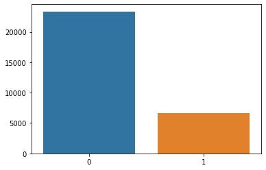

```python
a = credit_orign_df['target'].value_counts()
sns.barplot(x =a.index , y=a.values, data=credit_orign_df)
a
```

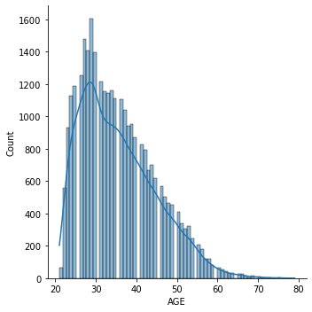

```python
sns.displot(credit_orign_df['AGE'], kde = True);
```

> - 나이 별 분포도 확인

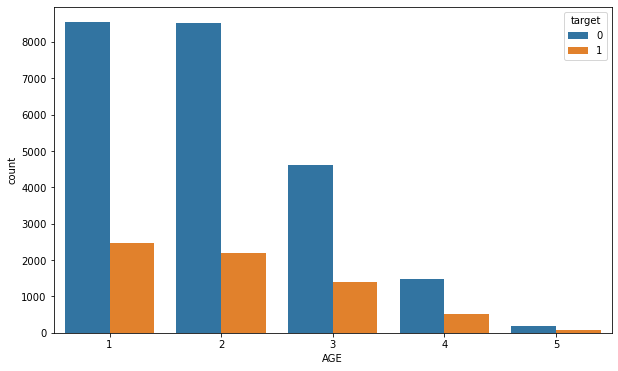

```python
def get_category(age):
    cat = ''

    if age <= 30: cat = 1
    elif age <= 40: cat = 2
    elif age <= 50: cat = 3
    elif age <= 60: cat = 4
    else : cat = 5

    return cat
credit_orign_df['AGE'] = credit_orign_df['AGE'].apply(lambda x : get_category(x))

plt.figure(figsize=(10,6))

sns.countplot(x='AGE', hue = 'target',  data=credit_orign_df);
```

> - 연속형 변수인 AGE를 나이 구간에 따라 범주형 변수로 변환하고 시각화

```
2    14030
1    10585
3     4917
5      280
4      123
6       51
0       14
Name: EDUCATION, dtype: int64
```

```
2    14030
1    10585
3     4917
4      468
Name: EDUCATION, dtype: int64
```

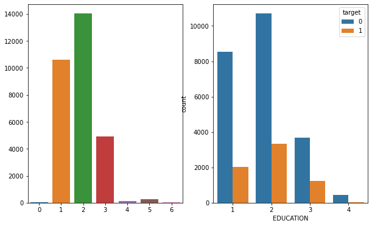

```python
fig, ax = plt.subplots(figsize = (10, 6),nrows = 1, ncols = 2)
e = credit_orign_df['EDUCATION'].value_counts()
sns.barplot(x = e.index, y= e.values, data=credit_orign_df ,ax = ax[0])
print(e)


credit_orign_df['EDUCATION'] = credit_orign_df['EDUCATION'].apply(lambda x : 4 if x >= 4 or x==0 else x)
sns.countplot(x = 'EDUCATION',hue='target' ,data = credit_orign_df, ax = ax[1]);
credit_orign_df['EDUCATION'].value_counts()
```

> - EDUCATION의 값이 4,5,6,0인 값들을 모두 4로 수정한 후 시각화

```
2    18112
1    11888
Name: SEX, dtype: int64
```

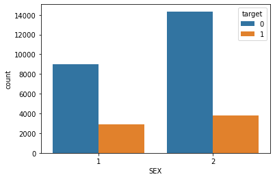

```python
sns.countplot(x = 'SEX',hue='target' ,data = credit_orign_df)
credit_orign_df['SEX'].value_counts()
```

> - 남녀 인원수와 성별에 따른 target 값 시각화 -> 여성일 경우 채무이행할 확률이 더 높음

```python
def bar_plot(feature_name , data =  credit_orign_df):
    fig, axs = plt.subplots(figsize=(16, 8), nrows=2, ncols=3)
    for i in range(2):
        for j in range(3):
            sns.barplot(x= feature_name + str((j + 1) + (i * 3)), y = 'target', data = data, ax= axs[i][j], ci = None)
```

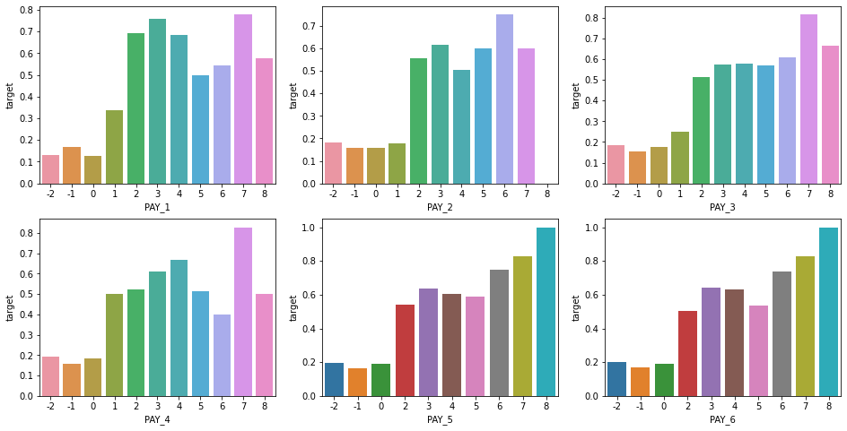

```python
bar_plot("PAY_")
```

> - PAY_1 ~ PAY_6 에 대한 target값 분포 시각화
> - 미납 기간이 길수록 불이행도가 높은 것을 확인

```python
credit_orign_df[['PAY_1','PAY_2','PAY_3','PAY_4','PAY_5','PAY_6']] = credit_orign_df[['PAY_1','PAY_2','PAY_3','PAY_4','PAY_5','PAY_6']].applymap(lambda x : 4 if x > 3 else x)
credit_df = credit_orign_df.copy()
credit_df['PAY_1'].value_counts()
```

```
 0    14737
-1     5686
 1     3688
-2     2759
 2     2667
 3      322
 4      141
Name: PAY_1, dtype: int64
```

> - PAY_1 ~ PAY_6 의 값이 4 이상인 것들을 4로 모두 통일

```python
credit_orign_df.corr()
```

|  | LIMIT_BAL | SEX | EDUCATION | MARRIAGE | AGE | PAY_1 | PAY_2 | PAY_3 | PAY_4 | PAY_5 | ... | BILL_AMT4 | BILL_AMT5 | BILL_AMT6 | PAY_AMT1 | PAY_AMT2 | PAY_AMT3 | PAY_AMT4 | PAY_AMT5 | PAY_AMT6 | target |
| --- | --- | --- | --- | --- | --- | --- | --- | --- | --- | --- | --- | --- | --- | --- | --- | --- | --- | --- | --- | --- | --- |
| LIMIT_BAL | 1.000000 | 0.024755 | -0.231088 | -0.108139 | 0.121925 | -0.275204 | -0.298975 | -0.289008 | -0.270815 | -0.252155 | ... | 0.293988 | 0.295562 | 0.290389 | 0.195236 | 0.178408 | 0.210167 | 0.203242 | 0.217202 | 0.219595 | -0.153520 |
| SEX | 0.024755 | 1.000000 | 0.013627 | -0.031389 | -0.082957 | -0.057395 | -0.070846 | -0.066219 | -0.060129 | -0.054769 | ... | -0.021880 | -0.017005 | -0.016733 | -0.000242 | -0.001391 | -0.008597 | -0.002229 | -0.001667 | -0.002766 | -0.039961 |
| EDUCATION | -0.231088 | 0.013627 | 1.000000 | -0.149134 | 0.184822 | 0.113739 | 0.130502 | 0.124053 | 0.118564 | 0.105596 | ... | -0.006131 | -0.012439 | -0.012646 | -0.041088 | -0.032793 | -0.044293 | -0.040949 | -0.045138 | -0.044061 | 0.033842 |
| MARRIAGE | -0.108139 | -0.031389 | -0.149134 | 1.000000 | -0.398799 | 0.020623 | 0.024997 | 0.032787 | 0.033643 | 0.036108 | ... | -0.023344 | -0.025393 | -0.021207 | -0.005979 | -0.008093 | -0.003541 | -0.012659 | -0.001205 | -0.006641 | -0.024339 |
| AGE | 0.121925 | -0.082957 | 0.184822 | -0.398799 | 1.000000 | -0.032992 | -0.042667 | -0.046038 | -0.044189 | -0.048206 | ... | 0.042587 | 0.039651 | 0.037255 | 0.021332 | 0.017899 | 0.025961 | 0.016488 | 0.016076 | 0.017218 | 0.016690 |
| PAY_1 | -0.275204 | -0.057395 | 0.113739 | 0.020623 | -0.032992 | 1.000000 | 0.663514 | 0.568716 | 0.536236 | 0.510054 | ... | 0.179179 | 0.180559 | 0.177070 | -0.079531 | -0.070530 | -0.070852 | -0.064201 | -0.058898 | -0.060110 | 0.328055 |
| PAY_2 | -0.298975 | -0.070846 | 0.130502 | 0.024997 | -0.042667 | 0.663514 | 1.000000 | 0.767597 | 0.666497 | 0.629289 | ... | 0.222798 | 0.221737 | 0.219866 | -0.080798 | -0.059036 | -0.055793 | -0.046571 | -0.037033 | -0.036418 | 0.264325 |
| PAY_3 | -0.289008 | -0.066219 | 0.124053 | 0.032787 | -0.046038 | 0.568716 | 0.767597 | 1.000000 | 0.775401 | 0.682345 | ... | 0.232060 | 0.229804 | 0.226920 | 0.002529 | -0.067023 | -0.053157 | -0.045698 | -0.035240 | -0.035453 | 0.234774 |
| PAY_4 | -0.270815 | -0.060129 | 0.118564 | 0.033643 | -0.044189 | 0.536236 | 0.666497 | 0.775401 | 1.000000 | 0.809169 | ... | 0.256277 | 0.253018 | 0.249082 | -0.007701 | -0.000785 | -0.069544 | -0.042845 | -0.032603 | -0.025506 | 0.215119 |
| PAY_5 | -0.252155 | -0.054769 | 0.105596 | 0.036108 | -0.048206 | 0.510054 | 0.629289 | 0.682345 | 0.809169 | 1.000000 | ... | 0.283427 | 0.281098 | 0.273525 | -0.004543 | -0.002122 | 0.010981 | -0.058332 | -0.032505 | -0.021984 | 0.201838 |
| PAY_6 | -0.237640 | -0.043410 | 0.089948 | 0.035107 | -0.043570 | 0.477749 | 0.582637 | 0.627924 | 0.702052 | 0.807389 | ... | 0.276638 | 0.301662 | 0.295571 | 0.000009 | -0.004170 | 0.007456 | 0.020910 | -0.046188 | -0.024416 | 0.184189 |
| BILL_AMT1 | 0.285430 | -0.033642 | 0.016597 | -0.023472 | 0.047473 | 0.187568 | 0.235889 | 0.213308 | 0.212314 | 0.216639 | ... | 0.860272 | 0.829779 | 0.802650 | 0.140277 | 0.099355 | 0.156887 | 0.158303 | 0.167026 | 0.179341 | -0.019644 |
| BILL_AMT2 | 0.278314 | -0.031183 | 0.011980 | -0.021602 | 0.045291 | 0.190377 | 0.236219 | 0.242605 | 0.235926 | 0.237377 | ... | 0.892482 | 0.859778 | 0.831594 | 0.280365 | 0.100851 | 0.150718 | 0.147398 | 0.157957 | 0.174256 | -0.014193 |
| BILL_AMT3 | 0.283236 | -0.024563 | 0.006714 | -0.024909 | 0.044853 | 0.180086 | 0.224908 | 0.232535 | 0.255467 | 0.254099 | ... | 0.923969 | 0.883910 | 0.853320 | 0.244335 | 0.316936 | 0.130011 | 0.143405 | 0.179712 | 0.182326 | -0.014076 |
| BILL_AMT4 | 0.293988 | -0.021880 | -0.006131 | -0.023344 | 0.042587 | 0.179179 | 0.222798 | 0.232060 | 0.256277 | 0.283427 | ... | 1.000000 | 0.940134 | 0.900941 | 0.233012 | 0.207564 | 0.300023 | 0.130191 | 0.160433 | 0.177637 | -0.010156 |
| BILL_AMT5 | 0.295562 | -0.017005 | -0.012439 | -0.025393 | 0.039651 | 0.180559 | 0.221737 | 0.229804 | 0.253018 | 0.281098 | ... | 0.940134 | 1.000000 | 0.946197 | 0.217031 | 0.181246 | 0.252305 | 0.293118 | 0.141574 | 0.164184 | -0.006760 |
| BILL_AMT6 | 0.290389 | -0.016733 | -0.012646 | -0.021207 | 0.037255 | 0.177070 | 0.219866 | 0.226920 | 0.249082 | 0.273525 | ... | 0.900941 | 0.946197 | 1.000000 | 0.199965 | 0.172663 | 0.233770 | 0.250237 | 0.307729 | 0.115494 | -0.005372 |
| PAY_AMT1 | 0.195236 | -0.000242 | -0.041088 | -0.005979 | 0.021332 | -0.079531 | -0.080798 | 0.002529 | -0.007701 | -0.004543 | ... | 0.233012 | 0.217031 | 0.199965 | 1.000000 | 0.285576 | 0.252191 | 0.199558 | 0.148459 | 0.185735 | -0.072929 |
| PAY_AMT2 | 0.178408 | -0.001391 | -0.032793 | -0.008093 | 0.017899 | -0.070530 | -0.059036 | -0.067023 | -0.000785 | -0.002122 | ... | 0.207564 | 0.181246 | 0.172663 | 0.285576 | 1.000000 | 0.244770 | 0.180107 | 0.180908 | 0.157634 | -0.058579 |
| PAY_AMT3 | 0.210167 | -0.008597 | -0.044293 | -0.003541 | 0.025961 | -0.070852 | -0.055793 | -0.053157 | -0.069544 | 0.010981 | ... | 0.300023 | 0.252305 | 0.233770 | 0.252191 | 0.244770 | 1.000000 | 0.216325 | 0.159214 | 0.162740 | -0.056250 |
| PAY_AMT4 | 0.203242 | -0.002229 | -0.040949 | -0.012659 | 0.016488 | -0.064201 | -0.046571 | -0.045698 | -0.042845 | -0.058332 | ... | 0.130191 | 0.293118 | 0.250237 | 0.199558 | 0.180107 | 0.216325 | 1.000000 | 0.151830 | 0.157834 | -0.056827 |
| PAY_AMT5 | 0.217202 | -0.001667 | -0.045138 | -0.001205 | 0.016076 | -0.058898 | -0.037033 | -0.035240 | -0.032603 | -0.032505 | ... | 0.160433 | 0.141574 | 0.307729 | 0.148459 | 0.180908 | 0.159214 | 0.151830 | 1.000000 | 0.154896 | -0.055124 |
| PAY_AMT6 | 0.219595 | -0.002766 | -0.044061 | -0.006641 | 0.017218 | -0.060110 | -0.036418 | -0.035453 | -0.025506 | -0.021984 | ... | 0.177637 | 0.164184 | 0.115494 | 0.185735 | 0.157634 | 0.162740 | 0.157834 | 0.154896 | 1.000000 | -0.053183 |
| target | -0.153520 | -0.039961 | 0.033842 | -0.024339 | 0.016690 | 0.328055 | 0.264325 | 0.234774 | 0.215119 | 0.201838 | ... | -0.010156 | -0.006760 | -0.005372 | -0.072929 | -0.058579 | -0.056250 | -0.056827 | -0.055124 | -0.053183 | 1.000000 |

24 rows × 24 columns

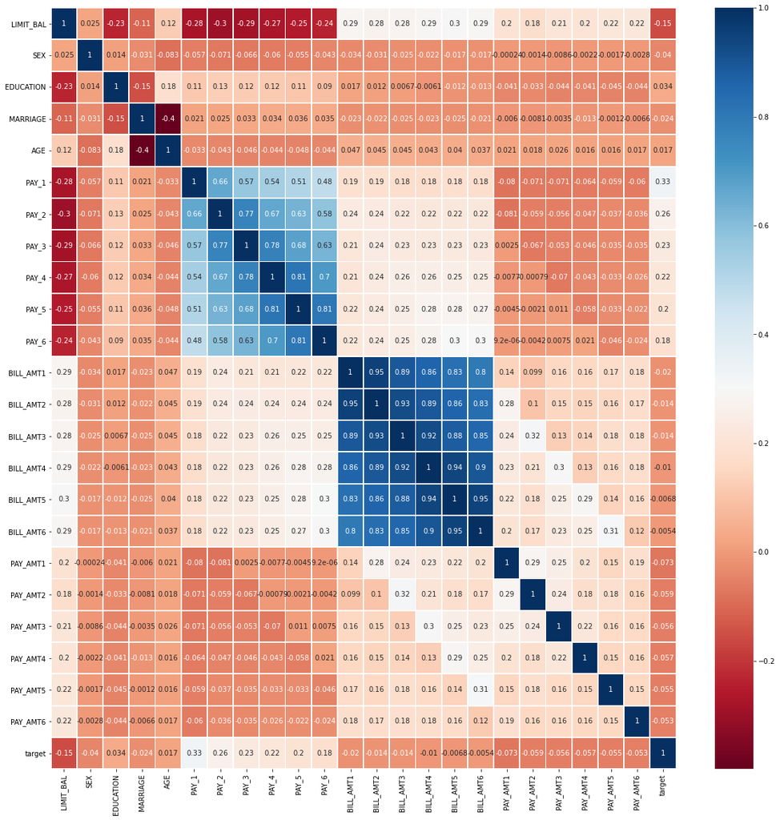

```python
plt.figure(figsize=(20, 20))
corr = credit_orign_df.corr()
sns.heatmap(corr, annot = True , cmap='RdBu', linewidth = 1)
```

> - 상관계수 시각화 -> PAY_1가 제일 높은 값을 나타냄

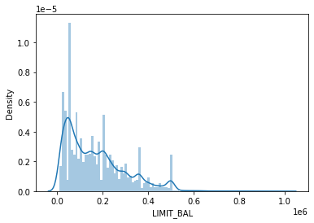

```python
sns.distplot(credit_df['LIMIT_BAL'], bins = 100);
```

```python
def dist_plot(feature_name, color = 'blue'):
    fig, axs = plt.subplots(figsize=(16, 8), nrows=2, ncols=3)
    for i in range(2):
        for j in range(3):
            sns.distplot(credit_df[feature_name+ str((j + 1) + (i * 3))], bins = 100, ax = axs[i][j], color= 'blue')
```

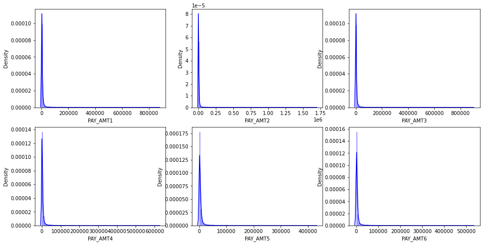

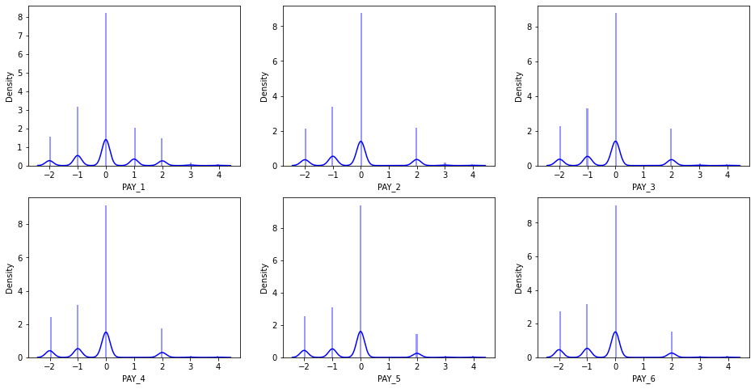

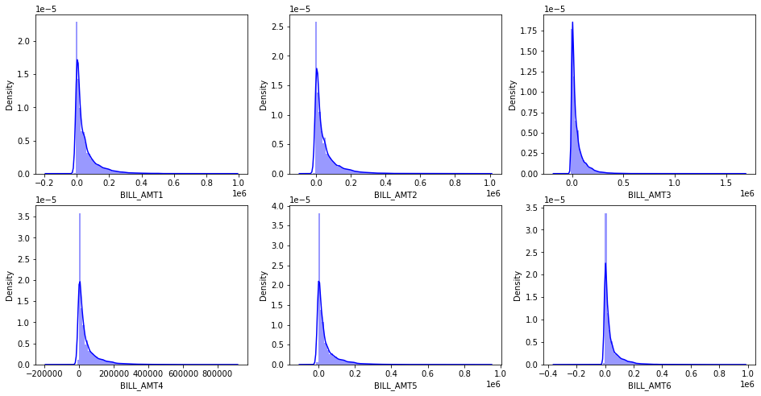

```python
dist_plot("PAY_AMT")
dist_plot("PAY_")
dist_plot("BILL_AMT")
```

> - PAY_1 ~ PAY_6, PAY_AMT1 ~ PAY_AMT6, BILL_AMT1 ~ BILL_AMT6 시각화

```python
import numpy as np

def get_outlier(df=None, column=None, weight=1.5):
    # fraud에 해당하는 column 데이터만 추출, 1/4 분위와 3/4 분위 지점을 np.percentile로 구함.
    fraud = df[column]
    quantile_25 = np.percentile(fraud.values, 25)
    quantile_75 = np.percentile(fraud.values, 75)
    # IQR을 구하고, IQR에 1.5를 곱하여 최대값과 최소값 지점 구함.
    iqr = quantile_75 - quantile_25
    iqr_weight = iqr * weight
    lowest_val = quantile_25 - iqr_weight
    highest_val = quantile_75 + iqr_weight
    # 최대값 보다 크거나, 최소값 보다 작은 값을 아웃라이어로 설정하고 DataFrame index 반환.
    outlier_index = fraud[(fraud < lowest_val) | (fraud > highest_val)].index
    return outlier_index
```

```python
outlier_index = get_outlier(df=credit_df, column='PAY_1', weight = 3)
print('이상치 데이터 인덱스:', outlier_index)
credit_df.drop(outlier_index, axis=0, inplace=True)
```

[output not shown]

> - 여러 피쳐들중 전체 데이터의 패턴에서 벗어난 이상치들을 제거해보았으나 성능이 나아지지 않고 오히려 떨어졌다. -> 이상치가 아닌 값이거나, 이상치 제거가 의사결정 나무 알고리즘 향상에 영향을 주지않는다

```python
credit_df['BILL_AMT1'] = credit_df['BILL_AMT1']+credit_df['BILL_AMT2']+credit_df['BILL_AMT3']+credit_df['BILL_AMT4']+credit_df['BILL_AMT5']+credit_df['BILL_AMT6']
credit_df['PAY_AMT1'] = credit_df['PAY_AMT1']+credit_df['PAY_AMT2']+credit_df['PAY_AMT3']+credit_df['PAY_AMT4']+credit_df['PAY_AMT5']+credit_df['PAY_AMT6']
```

```python
credit_df = credit_df.drop(['BILL_AMT2','BILL_AMT3','BILL_AMT4','BILL_AMT5','BILL_AMT6','PAY_AMT2','PAY_AMT3','PAY_AMT4','PAY_AMT5','PAY_AMT6'], axis = 1)
```

> - 비슷한 경향을 보이는 PAY_AMT1 ~ PAY_AMT6, BILL_AMT1 ~ BILL_AMT6 을 각각 모두 더해서 PAY_AMT1, BILL_AMT1에 저장
> - PAY_AMT1, BILL_AMT1 을 제외하고 feature 삭제

```python
log_scaled_features =['LIMIT_BAL','BILL_AMT1','PAY_AMT1']
credit_df[log_scaled_features] = credit_df[log_scaled_features].applymap(lambda x: np.log1p(x) if x > 0 else -np.log1p(-x))
credit_df
```

|  | LIMIT_BAL | SEX | EDUCATION | MARRIAGE | AGE | PAY_1 | PAY_2 | PAY_3 | PAY_4 | PAY_5 | PAY_6 | BILL_AMT1 | PAY_AMT1 | target |
| --- | --- | --- | --- | --- | --- | --- | --- | --- | --- | --- | --- | --- | --- | --- |
| 0 | 9.903538 | 2 | 2 | 1 | 1 | 2 | 2 | -1 | -1 | -2 | -2 | 8.949625 | 6.536692 | 1 |
| 1 | 11.695255 | 2 | 2 | 2 | 1 | -1 | 2 | 0 | 0 | 0 | 2 | 9.745546 | 8.517393 | 1 |
| 2 | 11.407576 | 2 | 2 | 2 | 2 | 0 | 0 | 0 | 0 | 0 | 0 | 11.529330 | 9.307376 | 0 |
| 3 | 10.819798 | 2 | 2 | 1 | 2 | 0 | 0 | 0 | 0 | 0 | 0 | 12.351622 | 9.034677 | 0 |
| 4 | 10.819798 | 1 | 2 | 1 | 4 | -1 | 0 | -1 | 0 | 0 | 0 | 11.602218 | 10.986140 | 0 |
| ... | ... | ... | ... | ... | ... | ... | ... | ... | ... | ... | ... | ... | ... | ... |
| 29995 | 12.301387 | 1 | 3 | 1 | 2 | 0 | 0 | 0 | 0 | 0 | 0 | 13.494410 | 10.658459 | 0 |
| 29996 | 11.918397 | 1 | 3 | 2 | 3 | -1 | -1 | -1 | -1 | 0 | 0 | 9.960954 | 9.581283 | 0 |
| 29997 | 10.308986 | 1 | 2 | 2 | 2 | 4 | 3 | 2 | -1 | 0 | 0 | 11.163325 | 10.351405 | 1 |
| 29998 | 11.289794 | 1 | 3 | 1 | 3 | 1 | -1 | 0 | 0 | 0 | -1 | 12.493550 | 11.899425 | 1 |
| 29999 | 10.819798 | 1 | 2 | 1 | 3 | 0 | 0 | 0 | 0 | 0 | 0 | 12.349632 | 9.025095 | 1 |

30000 rows × 14 columns

> - distplot으로 확인한 결과 데이터의 왜곡도가 심하다고 생각하여 log1p를 해줌으로써 해결

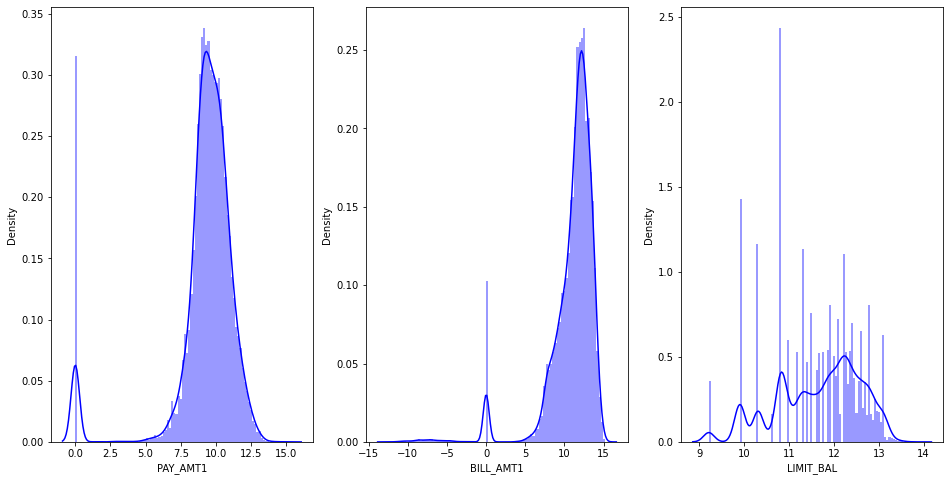

```python
fig, axs = plt.subplots(figsize=(16, 8), nrows=1, ncols=3)
sns.distplot(credit_df['PAY_AMT1'], bins = 100, ax = axs[0], color= 'blue')
sns.distplot(credit_df['BILL_AMT1'], bins = 100, ax = axs[1], color= 'blue')
sns.distplot(credit_df['LIMIT_BAL'], bins = 100, ax = axs[2], color= 'blue')
```

> - log1p 이후 PAY_AMT1 , BILL_AMT1 ,LIMIT_BAL 시각화

## 학습,-테스트-데이터-분리

```python
features = credit_df.iloc[:,:-1].values
target = credit_df.iloc[:,-1].values
```

```python
seed = 5764

# 학습, 테스트 데이터 분리 (0.7:0.3)
x_train, x_test, y_train, y_test = train_test_split(features, target, test_size=0.3, random_state=seed, stratify= target)
print(f'train의 shape: {x_train.shape}, {y_train.shape} \ntest의 shape: {x_test.shape}, {y_test.shape}')
```

```
train의 shape: (21000, 13), (21000,)
test의 shape: (9000, 13), (9000,)
```

# 3. 의사결정나무 모델 구축 (Classification Tree)

```python
dt_clf = DecisionTreeClassifier(random_state=5764)
dt_clf.fit(x_train, y_train) # 학습
```

```
DecisionTreeClassifier(random_state=5764)
```

## 의사결정나무 모델 가시화

```python
# export_graphviz( )의 호출 결과로 out_file로 지정된 tree.dot 파일을 생성
export_graphviz(dt_clf, out_file="tree.dot", class_names = ['0','1'], feature_names = (credit_df.iloc[:,:-1]).columns, impurity=True, filled=True)
```

```python
print('[ max_depth의 제약이 없는 경우의 Decision Tree 시각화 ]')
# 위에서 생성된 tree.dot 파일을 Graphiviz 가 읽어서 시각화
with open("tree.dot") as f:
    dot_graph = f.read()
src = graphviz.Source(dot_graph)
src.view()
```

```
[ max_depth의 제약이 없는 경우의 Decision Tree 시각화 ]
```

```
'Source.gv.pdf'
```

> - tree의 깊이가 너무 깊어서 따로 pdf파일로 저장

# 4. 의사결정나무 모델 테스트

```python
def get_clf_eval(y_test, pred=None):
    confusion = mt.confusion_matrix( y_test, pred)
    accuracy = mt.accuracy_score(y_test , pred)
    precision = mt.precision_score(y_test , pred)
    recall = mt.recall_score(y_test , pred)
    f1 = mt.f1_score(y_test,pred)

    print('오차 행렬:')
    print(confusion)

    print('\n정확도: {0:.4f} \n정밀도: {1:.4f} \n재현율: {2:.4f} \n    F1: {3:.4f}'.format(accuracy, precision, recall, f1))
```

```python
y_pred = dt_clf.predict(x_test)

get_clf_eval(y_test,y_pred)
```

```
오차 행렬:
[[5747 1262]
 [1162  829]]

정확도: 0.7307
정밀도: 0.3965
재현율: 0.4164
    F1: 0.4062
```

> - 정확도 정밀도 재현율 f1 오차행렬 출력

## Cross Validation

```python
scores = cross_val_score(dt_clf, X = features, y = target, cv = 5)

print('Averaged results of cross validation: ', scores.mean())
```

```
Averaged results of cross validation:  0.7268000000000001
```

```python
pd.DataFrame(cross_validate(dt_clf, features, target, cv =5))
```

|  | fit_time | score_time | test_score |
| --- | --- | --- | --- |
| 0 | 0.164138 | 0.002996 | 0.714000 |
| 1 | 0.151791 | 0.004002 | 0.724333 |
| 2 | 0.152336 | 0.002183 | 0.729833 |
| 3 | 0.162165 | 0.002956 | 0.734333 |
| 4 | 0.176674 | 0.002049 | 0.731500 |

```python
# test set에 대한 스코어(정확도)
dt_clf.score(x_test, y_test)
```

```
0.7306666666666667
```

## feature importance

```
Feature importances:
[0.107 0.025 0.04  0.024 0.055 0.172 0.041 0.025 0.018 0.021 0.021 0.231
 0.221]
LIMIT_BAL : 0.107
SEX : 0.025
EDUCATION : 0.040
MARRIAGE : 0.024
AGE : 0.055
PAY_1 : 0.172
PAY_2 : 0.041
PAY_3 : 0.025
PAY_4 : 0.018
PAY_5 : 0.021
PAY_6 : 0.021
BILL_AMT1 : 0.231
PAY_AMT1 : 0.221
```

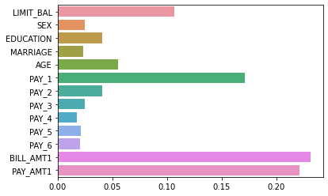

```python
# feature importance 추출
print("Feature importances:\n{0}".format(np.round(dt_clf.feature_importances_, 3)))

# feature별 importance 매핑
for name, value in zip((credit_df.iloc[:,:-1]).columns , dt_clf.feature_importances_):
    print('{0} : {1:.3f}'.format(name, value))

# feature importance를 column 별로 시각화 하기
sns.barplot(x=dt_clf.feature_importances_ , y=(credit_df.iloc[:,:-1]).columns)
```

> - 결정 트리에서 각 feature들의 중요도 시각화

# 5. 가지치기 수행 (Pruning phase)

```python
pruned_dt_clf = DecisionTreeClassifier(max_depth=2, random_state=5764)
pruned_dt_clf .fit(x_train, y_train)

print("Accuracy of training set: {:.3f}".format(pruned_dt_clf.score(x_train, y_train)))
print("Accuracy of test set: {:.3f}".format(pruned_dt_clf.score(x_test, y_test)))
```

```
Accuracy of training set: 0.821
Accuracy of test set: 0.818
```

## 의사결정나무 모델 가시화 및 설명

```python
export_graphviz(pruned_dt_clf, out_file="tree.dot", class_names = ['0','1'], feature_names = credit_df.iloc[:,:-1].columns, impurity=True, filled=True)
print('[ max_depth의 제약이 있는 경우의 Decision Tree 시각화 ]')
# 위에서 생성된 tree.dot 파일을 Graphiviz 가 읽어서 시각화
with open("tree.dot") as f:
    dot_graph = f.read()
src = graphviz.Source(dot_graph)
# src.view()
src
```

```
[ max_depth의 제약이 있는 경우의 Decision Tree 시각화 ]
```

[figure not shown]

> - 맨 왼쪽의 리프노드는 PAY_1이 1.5 이하, PAY_2가 1.5이하 일 경우로 17280개의 데이터중 14800개가 class '0'(채무 이행)으로 분류하기 때문에 예측 클래스를 0으로 결정한다.
> - 두 번째 리프노드는 PAY_1이 1.5 이하, PAY_2가 1.5보다 클 경우로 1519개의 데이터중 885개가 class '0'(채무 이행)으로 분류하기 때문에 예측 클래스를 0으로 결정한다.
> - 세 번째 리프노드는 PAY_1이 1.5 보다 크고, PAY_3가 -0.5이하 일 경우로 129개의 데이터중 76개가 class '0'(채무 이행)으로 분류하기 때문에 예측 클래스를 0으로 결정한다.
> - 네 번째 리프노드는 PAY_1이 1.5 보다 크고, PAY_3가 -0.5보다 클 경우로 2072개의 데이터중 1478개가 class '1'(채무 불이행)으로 분류하기 때문에 예측 클래스를 1로 결정한다.
> - 각 노드의 색깔은 target값을 의미하는데 주황색은 class '0' (채무 이행) , 파란색은 class '1'을 뜻한다. 지니계수가 낮을수록 색깔이 진하게 표현되는 것을 확인할 수 있다.

```python
depth = [20,16,12,8,4]
# max_depth 값을 변화 시키면서 그때마다 학습과 테스트 셋에서의 예측 성능 측정
for d in depth:
    dt_clf = DecisionTreeClassifier(max_depth=d, random_state=5764)
    dt_clf.fit(x_train , y_train)
    pred = dt_clf.predict(x_test)
    accuracy = mt.accuracy_score(y_test , pred)
    print('max_depth = {0} 정확도: {1:.4f}'.format(d , accuracy))
    get_clf_eval(y_test, pred)
```

```
max_depth = 20 정확도: 0.7569
오차 행렬:
[[6049  960]
 [1228  763]]

정확도: 0.7569
정밀도: 0.4428
재현율: 0.3832
    F1: 0.4109
max_depth = 16 정확도: 0.7829
오차 행렬:
[[6284  725]
 [1229  762]]

정확도: 0.7829
정밀도: 0.5124
재현율: 0.3827
    F1: 0.4382
max_depth = 12 정확도: 0.8034
오차 행렬:
[[6525  484]
 [1285  706]]

정확도: 0.8034
정밀도: 0.5933
재현율: 0.3546
    F1: 0.4439
max_depth = 8 정확도: 0.8154
오차 행렬:
[[6572  437]
 [1224  767]]

정확도: 0.8154
정밀도: 0.6370
재현율: 0.3852
    F1: 0.4801
max_depth = 4 정확도: 0.8200
오차 행렬:
[[6668  341]
 [1279  712]]

정확도: 0.8200
정밀도: 0.6762
재현율: 0.3576
    F1: 0.4678
```

> - 깊이가 얕아질수록 test set에 대한 정확도가 높아지는 것을 확인할 수 있다.

# 6. 최적의 하이퍼 파라미터

```python
from sklearn.model_selection import GridSearchCV

params = {
    'max_depth' : [4, 6, 8 ,10, 12, 16],

    'min_samples_split' : [5,10, 20, 30, 50, 80, 100]
}

grid_cv = GridSearchCV(dt_clf, param_grid=params, scoring='accuracy', cv=5, verbose=1 )
grid_cv.fit(x_train , y_train)
print('GridSearchCV 최고 평균 정확도 수치:{0:.4f}'.format(grid_cv.best_score_))
print('GridSearchCV 최적 하이퍼 파라미터:', grid_cv.best_params_)
```

```
Fitting 5 folds for each of 42 candidates, totalling 210 fits
GridSearchCV 최고 평균 정확도 수치:0.8216
GridSearchCV 최적 하이퍼 파라미터: {'max_depth': 4, 'min_samples_split': 5}
```

> - 트리의 최대 깊이를 정하는 max_depth와 노드를 분할하기 위한 최소한의 샘플 데이터수를 정하는 min_samples_split을 바꿔주면 최적의 하이퍼 파라미터를 결정

```python
#### GridSearchCV객체의 cv_results_ 속성을 DataFrame으로 생성.
cv_results_df = pd.DataFrame(grid_cv.cv_results_)

# max_depth 파라미터 값과 그때의 테스트(Evaluation)셋, 학습 데이터 셋의 정확도 수치 추출
cv_results_df[['param_max_depth','param_min_samples_split', 'mean_test_score']]
```

|  | param_max_depth | param_min_samples_split | mean_test_score |
| --- | --- | --- | --- |
| 0 | 4 | 5 | 0.821571 |
| 1 | 4 | 10 | 0.821571 |
| 2 | 4 | 20 | 0.821476 |
| 3 | 4 | 30 | 0.821429 |
| 4 | 4 | 50 | 0.821429 |
| 5 | 4 | 80 | 0.821429 |
| 6 | 4 | 100 | 0.821429 |
| 7 | 6 | 5 | 0.819381 |
| 8 | 6 | 10 | 0.819524 |
| 9 | 6 | 20 | 0.819762 |
| 10 | 6 | 30 | 0.819619 |
| 11 | 6 | 50 | 0.819476 |
| 12 | 6 | 80 | 0.819381 |
| 13 | 6 | 100 | 0.820000 |
| 14 | 8 | 5 | 0.814952 |
| 15 | 8 | 10 | 0.815190 |
| 16 | 8 | 20 | 0.815000 |
| 17 | 8 | 30 | 0.814857 |
| 18 | 8 | 50 | 0.816048 |
| 19 | 8 | 80 | 0.815571 |
| 20 | 8 | 100 | 0.816333 |
| 21 | 10 | 5 | 0.809762 |
| 22 | 10 | 10 | 0.810143 |
| 23 | 10 | 20 | 0.809238 |
| 24 | 10 | 30 | 0.809333 |
| 25 | 10 | 50 | 0.810524 |
| 26 | 10 | 80 | 0.811238 |
| 27 | 10 | 100 | 0.814095 |
| 28 | 12 | 5 | 0.804095 |
| 29 | 12 | 10 | 0.804381 |
| 30 | 12 | 20 | 0.804286 |
| 31 | 12 | 30 | 0.804048 |
| 32 | 12 | 50 | 0.806238 |
| 33 | 12 | 80 | 0.808143 |
| 34 | 12 | 100 | 0.810905 |
| 35 | 16 | 5 | 0.785571 |
| 36 | 16 | 10 | 0.788667 |
| 37 | 16 | 20 | 0.791857 |
| 38 | 16 | 30 | 0.795476 |
| 39 | 16 | 50 | 0.802762 |
| 40 | 16 | 80 | 0.806571 |
| 41 | 16 | 100 | 0.808619 |

```python
dt_clf = DecisionTreeClassifier(max_depth=4, min_samples_split = 20)
dt_clf.fit(x_train , y_train)
pred = dt_clf.predict(x_test)
get_clf_eval(y_test, pred)
```

```
오차 행렬:
[[6668  341]
 [1279  712]]

정확도: 0.8200
정밀도: 0.6762
재현율: 0.3576
    F1: 0.4678
```

# 7. 의사결정나무의 특징 코멘트

> 본 실험을 수행하면서 가장 먼저 의사결정나무의 장점 중 하나인 '직관적인 해석 가능함' 을 느꼈는데, 트리를 시각화로 표현이 가능하기 때문에 어떤 규칙을 가지고 클래스가 분류되었는지 확인할 수 있는 점에서 쉽고 직관적인 알고리즘이라고 느꼈다.

> 위의 데이터에 있는 연속형 변수와 범주형 변수 모두 취급 가능하다는 것을 알게되었고, 연속형 변수에 대해 예측력이 비교적 낮은 것을 느꼈다.

> 해당 모델의 가장 큰 문제점은 과적합으로 인한 정확도 감소이다. 모든 데이터가 분류되는 상황을 만들기 위해 계속해서 규칙을 만들어 내기때문에 의사결정나무의 깊이를 제한할 수 있는 파라미터를 반드시 설정해야함을 느꼈다. 위의 전처리 과정에서 feature들을 통합하고 drop을 통해 삭제해줌으로써 성능개선이 일어났고, 이를 통해 feature가 많을수록 트리 구조가 깊어져 과적합이 일어난다는 것을 알게 되었다